Import required libraries

```python
import pandas as pd
import seaborn as sns
import matplotlib.pyplot as plt
from scipy.stats import f_oneway
import numpy as np
from statsmodels.stats.multicomp import pairwise_tukeyhsd
import pathlib
```

# Read and explore data

- 1 string column
- 13 numeric columns
- total of 14 columns
- No NA values

Meaning of each column:

- credit.policy: 1 if the customer meets the credit underwriting criteria of LendingClub.com, and 0 otherwise. purpose: The purpose of the loan (takes values "credit_card", "debt_consolidation", "educational", "major_purchase", "small_business", and "all_other").
- int.rate: The interest rate of the loan, as a proportion (a rate of 11% would be stored as 0.11). Borrowers judged by LendingClub.com to be more risky are assigned higher interest rates.
- installment: The monthly installments owed by the borrower if the loan is funded.
- log.annual.inc: The natural log of the self-reported annual income of the borrower. dti: The debt-to-income ratio of the borrower (amount of debt divided by annual income).
- fico: The FICO credit score of the borrower. days.with.cr.line: The number of days the borrower has had a credit line.
- revol.bal: The borrower's revolving balance (amount unpaid at the end of the credit card billing cycle).
- revol.util: The borrower's revolving line utilization rate (the amount of the credit line used relative to total credit available).
- inq.last.6mths: The borrower's number of inquiries by creditors in the last 6 months.
- delinq.2yrs: The number of times the borrower had been 30+ days past due on a payment in the past 2 years.
- pub.rec: The borrower's number of derogatory public records (bankruptcy filings, tax liens, or judgments).

Several columns don't have have a good range/ variance, meaning they may not be ideal features for machine learning models. Eg: `nq.last.6mths`, `delinq.2yrs`, `pub.rec`

```python
df = pd.read_csv("../data/raw/loan_data.csv")
print(df.isna().sum())

# Convert 0 and 1s column to boolean
df['credit.policy'] = df['credit.policy'].map({0: False, 1: True})
df['not.fully.paid'] = df['not.fully.paid'].map({0: False, 1: True})

# Create path to save figures and check existance of directory
fig_dir = pathlib.Path("../reports/figures")
fig_dir.mkdir(parents=True, exist_ok=True)

df.describe()  # Describe numeric properties of each column
```

```
credit.policy        0
purpose              0
int.rate             0
installment          0
log.annual.inc       0
dti                  0
fico                 0
days.with.cr.line    0
revol.bal            0
revol.util           0
inq.last.6mths       0
delinq.2yrs          0
pub.rec              0
not.fully.paid       0
dtype: int64
```

|  | int.rate | installment | log.annual.inc | dti | fico | days.with.cr.line | revol.bal | revol.util | inq.last.6mths | delinq.2yrs | pub.rec |
| --- | --- | --- | --- | --- | --- | --- | --- | --- | --- | --- | --- |
| count | 9578.000000 | 9578.000000 | 9578.000000 | 9578.000000 | 9578.000000 | 9578.000000 | 9.578000e+03 | 9578.000000 | 9578.000000 | 9578.000000 | 9578.000000 |
| mean | 0.122640 | 319.089413 | 10.932117 | 12.606679 | 710.846314 | 4560.767197 | 1.691396e+04 | 46.799236 | 1.577469 | 0.163708 | 0.062122 |
| std | 0.026847 | 207.071301 | 0.614813 | 6.883970 | 37.970537 | 2496.930377 | 3.375619e+04 | 29.014417 | 2.200245 | 0.546215 | 0.262126 |
| min | 0.060000 | 15.670000 | 7.547502 | 0.000000 | 612.000000 | 178.958333 | 0.000000e+00 | 0.000000 | 0.000000 | 0.000000 | 0.000000 |
| 25% | 0.103900 | 163.770000 | 10.558414 | 7.212500 | 682.000000 | 2820.000000 | 3.187000e+03 | 22.600000 | 0.000000 | 0.000000 | 0.000000 |
| 50% | 0.122100 | 268.950000 | 10.928884 | 12.665000 | 707.000000 | 4139.958333 | 8.596000e+03 | 46.300000 | 1.000000 | 0.000000 | 0.000000 |
| 75% | 0.140700 | 432.762500 | 11.291293 | 17.950000 | 737.000000 | 5730.000000 | 1.824950e+04 | 70.900000 | 2.000000 | 0.000000 | 0.000000 |
| max | 0.216400 | 940.140000 | 14.528354 | 29.960000 | 827.000000 | 17639.958330 | 1.207359e+06 | 119.000000 | 33.000000 | 13.000000 | 5.000000 |

```python
df.info()
```

```
<class 'pandas.core.frame.DataFrame'>
RangeIndex: 9578 entries, 0 to 9577
Data columns (total 14 columns):
 #   Column             Non-Null Count  Dtype
---  ------             --------------  -----
 0   credit.policy      9578 non-null   bool
 1   purpose            9578 non-null   object
 2   int.rate           9578 non-null   float64
 3   installment        9578 non-null   float64
 4   log.annual.inc     9578 non-null   float64
 5   dti                9578 non-null   float64
 6   fico               9578 non-null   int64
 7   days.with.cr.line  9578 non-null   float64
 8   revol.bal          9578 non-null   int64
 9   revol.util         9578 non-null   float64
 10  inq.last.6mths     9578 non-null   int64
 11  delinq.2yrs        9578 non-null   int64
 12  pub.rec            9578 non-null   int64
 13  not.fully.paid     9578 non-null   bool
dtypes: bool(2), float64(6), int64(5), object(1)
memory usage: 916.8+ KB
```

```python
df.head(10)
```

|  | credit.policy | purpose | int.rate | installment | log.annual.inc | dti | fico | days.with.cr.line | revol.bal | revol.util | inq.last.6mths | delinq.2yrs | pub.rec | not.fully.paid |
| --- | --- | --- | --- | --- | --- | --- | --- | --- | --- | --- | --- | --- | --- | --- |
| 0 | True | debt_consolidation | 0.1189 | 829.10 | 11.350407 | 19.48 | 737 | 5639.958333 | 28854 | 52.1 | 0 | 0 | 0 | False |
| 1 | True | credit_card | 0.1071 | 228.22 | 11.082143 | 14.29 | 707 | 2760.000000 | 33623 | 76.7 | 0 | 0 | 0 | False |
| 2 | True | debt_consolidation | 0.1357 | 366.86 | 10.373491 | 11.63 | 682 | 4710.000000 | 3511 | 25.6 | 1 | 0 | 0 | False |
| 3 | True | debt_consolidation | 0.1008 | 162.34 | 11.350407 | 8.10 | 712 | 2699.958333 | 33667 | 73.2 | 1 | 0 | 0 | False |
| 4 | True | credit_card | 0.1426 | 102.92 | 11.299732 | 14.97 | 667 | 4066.000000 | 4740 | 39.5 | 0 | 1 | 0 | False |
| 5 | True | credit_card | 0.0788 | 125.13 | 11.904968 | 16.98 | 727 | 6120.041667 | 50807 | 51.0 | 0 | 0 | 0 | False |
| 6 | True | debt_consolidation | 0.1496 | 194.02 | 10.714418 | 4.00 | 667 | 3180.041667 | 3839 | 76.8 | 0 | 0 | 1 | True |
| 7 | True | all_other | 0.1114 | 131.22 | 11.002100 | 11.08 | 722 | 5116.000000 | 24220 | 68.6 | 0 | 0 | 0 | True |
| 8 | True | home_improvement | 0.1134 | 87.19 | 11.407565 | 17.25 | 682 | 3989.000000 | 69909 | 51.1 | 1 | 0 | 0 | False |
| 9 | True | debt_consolidation | 0.1221 | 84.12 | 10.203592 | 10.00 | 707 | 2730.041667 | 5630 | 23.0 | 1 | 0 | 0 | False |

Correlation matrix: shows how each variable is correlated with all others, important how each variable affects each other and for feature selection.

Significant correlations, indicated by stronger colors hues are good candidates to be removed for feature selection

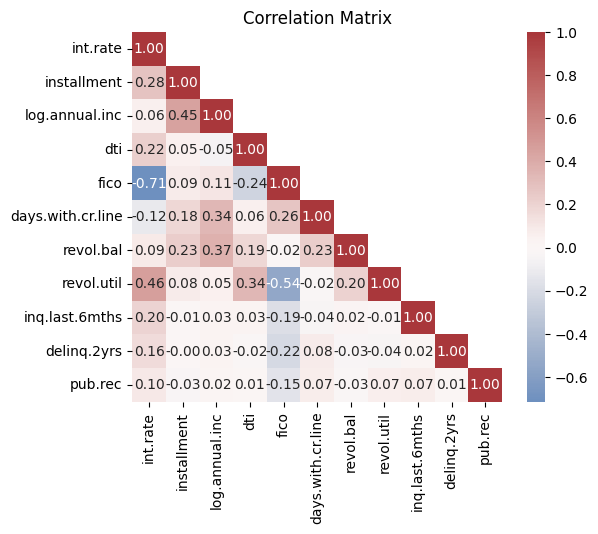

```python
# Remove non-numeric columns
df_selected = df.drop(["purpose", 'credit.policy', 'not.fully.paid'], axis=1)
corr = df_selected.corr()
mask = np.triu(np.ones_like(corr, dtype=bool), k=1)
sns.heatmap(corr, annot=True, mask=mask, fmt=".2f", cmap="vlag", center=0, square=True)
plt.title("Correlation Matrix")
plt.savefig(fig_dir / f"corr_matrix.png", dpi=300)
plt.show()
```

## FICO scores

Mostly concetraded between ~650 and ~750. Use The FICO scores classification: most people fall between 600 and 800 and there are no "Poor" scores on the data

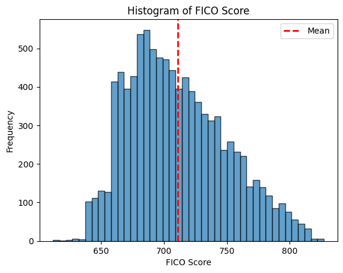

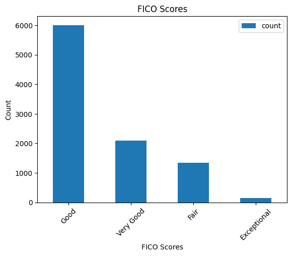

```python
mean = df['fico'].mean()
std = df['fico'].std()

plt.hist(df['fico'], bins='auto', alpha=0.7, edgecolor="black")
plt.title('Histogram of FICO Score')
plt.xlabel('FICO Score')
plt.ylabel('Frequency')
plt.axvline(mean, linestyle='--', color="red", linewidth=2, label='Mean')
plt.legend()
plt.savefig(fig_dir / f"hist_fico_scores.png", dpi=300)
plt.show()

# Bin FICO scores
bins = [579, 669, 739, 799, 850]
labels = ["Fair", "Good", "Very Good", "Exceptional"]  # No "Poor" on data
df['fico.score.labels'] = pd.cut(df['fico'], bins=bins, labels=labels, right=True, include_lowest=True)

df['fico.score.labels'].value_counts(sort=True).plot.bar()
plt.title("FICO Scores")
plt.xlabel("FICO Scores")
plt.xticks(rotation=45)
plt.ylabel("Count")
plt.legend().set_visible(False)  # legend not useful here

plt.legend()
plt.savefig(fig_dir / f"binned_fico_scores.png", dpi=300)
plt.show()
```

## Paid Loan Status

Comparing the Loan default frequency for various different variables can help determine which variable may be usefu to predict a default. Based on this analysis, we can determine that the following variables are not useful because they don't differ for the 2 groups of `not.fully.paid`:

- `installment`
- `log.annual.inc`
- `dti`
- `days.with.cr.line`
- `revol.bal`
- `delinq.2yrs`

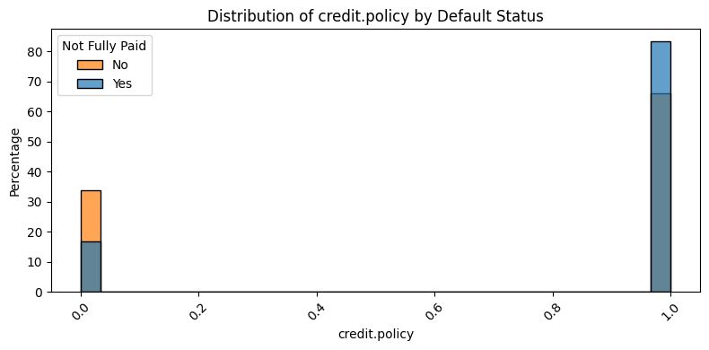

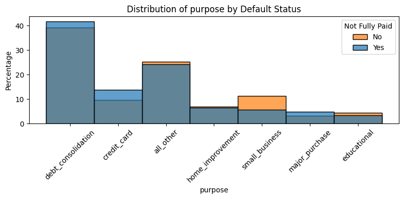

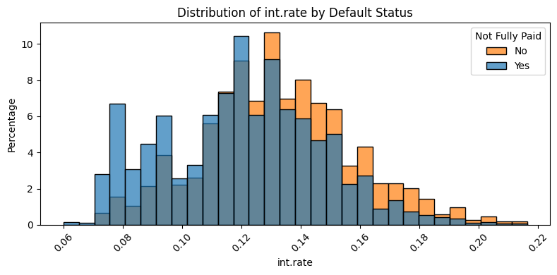

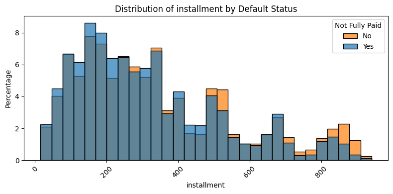

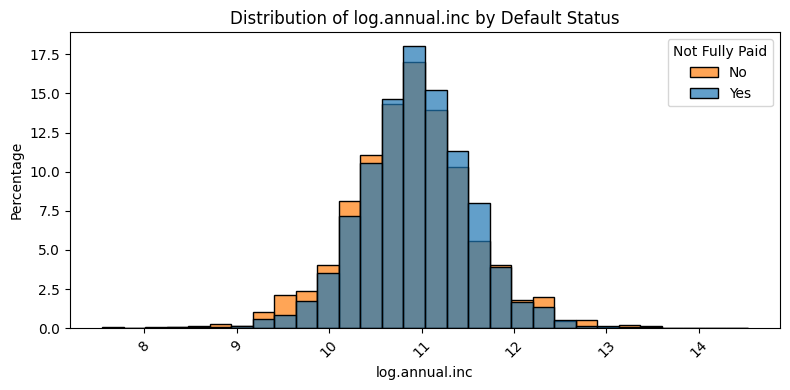

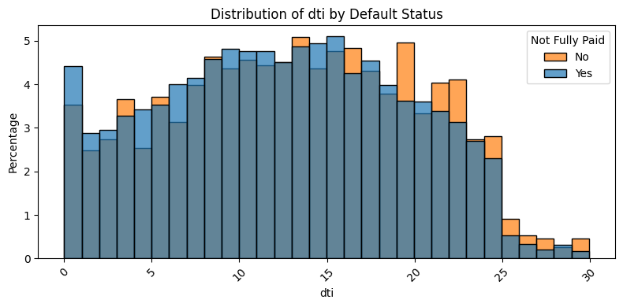

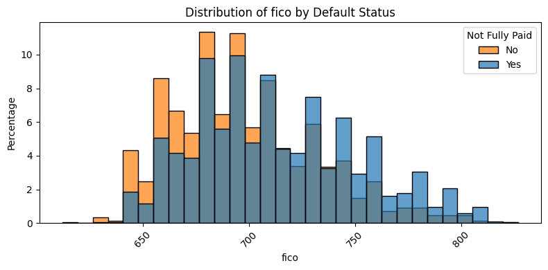

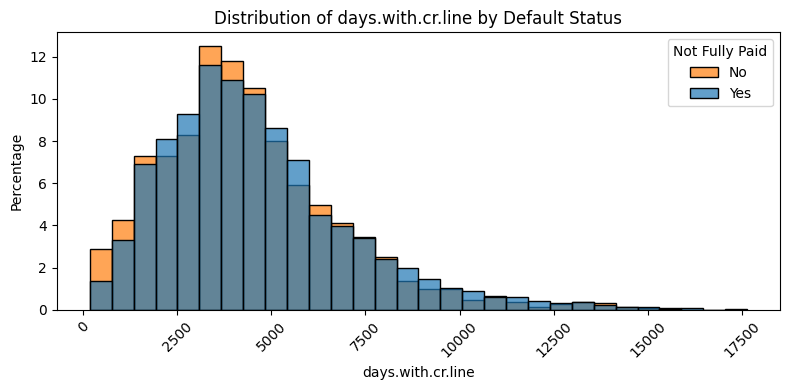

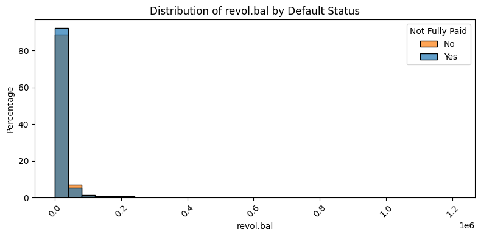

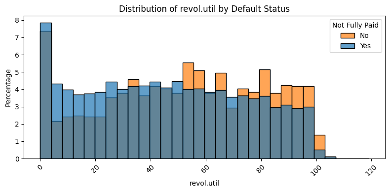

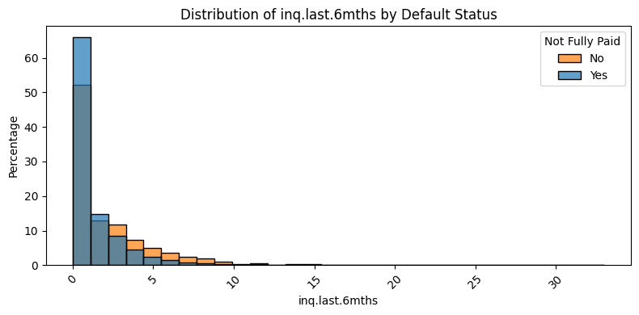

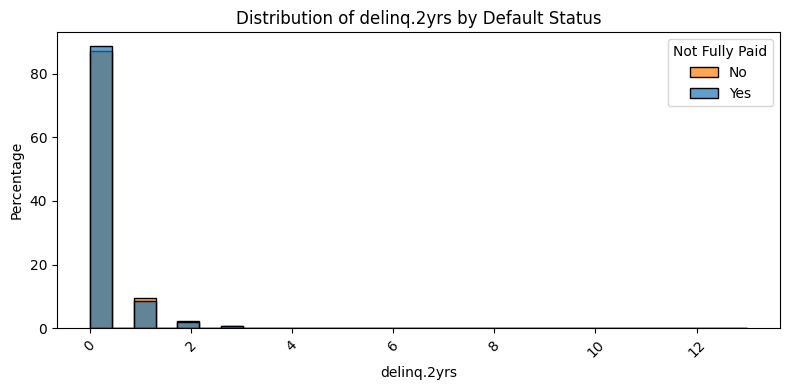

[1 more figures not shown]

```python
selected_columns = list(df.columns)

selected_columns = [x for x in selected_columns if x not in {"not.fully.paid", "delinq2yrs", "pub.rec"}]

for col in selected_columns:
    plt.figure(figsize=(8, 4))
    sns.histplot(
        data=df,
        x=col,
        hue="not.fully.paid",
        bins=30,
        element="bars",
        stat="percent",
        common_norm=False,
        alpha=0.7,
    )
    plt.title(f"Distribution of {col} by Default Status")
    plt.xlabel(col)
    plt.ylabel("Percentage")
    plt.xticks(rotation=45)
    plt.legend(title="Not Fully Paid", labels=["No","Yes"])
    plt.tight_layout()
    plt.savefig(fig_dir / f"hist_{col}_by_not.fully.paid.png", dpi=300)
    plt.show()
```

## Debt to Income Ratio (DTI)

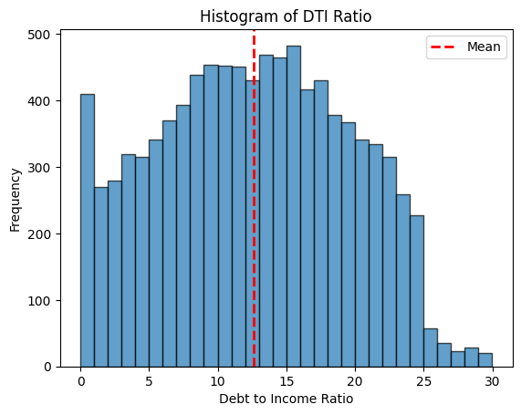

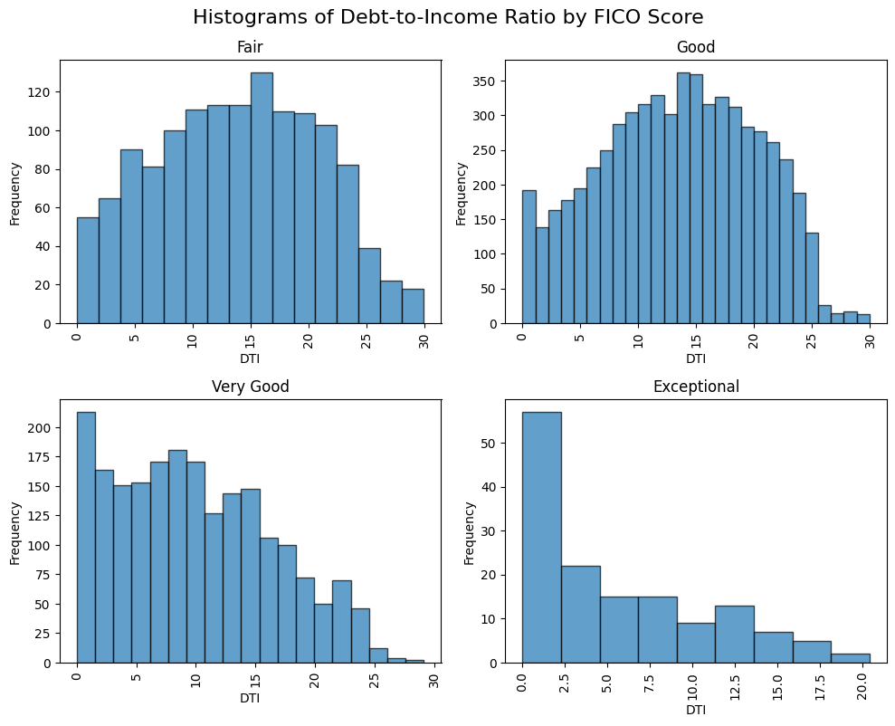

```
ANOVA F-statistic: nan
p-value: nan
    Multiple Comparison of Means - Tukey HSD, FWER=0.05
============================================================
   group1     group2  meandiff p-adj   lower   upper  reject
------------------------------------------------------------
Exceptional      Fair   8.2711    0.0   6.772  9.7703   True
Exceptional      Good   7.8747    0.0  6.4335  9.3159   True
Exceptional Very Good   4.4483    0.0  2.9755  5.9211   True
       Fair      Good  -0.3965 0.2007 -0.9144  0.1215  False
       Fair Very Good  -3.8228    0.0 -4.4231 -3.2225   True
       Good Very Good  -3.4263    0.0 -3.8622 -2.9904   True
------------------------------------------------------------
```

```python
# Central tendency and spread
mean = df["dti"].mean()
std = df['dti'].std()

# Hisotogram of dti ratio
plt.hist(df['dti'], bins='auto', alpha=0.7, edgecolor="black")
plt.title("Histogram of DTI Ratio")
plt.xlabel("Debt to Income Ratio")
plt.ylabel("Frequency")
plt.axvline(mean, linestyle='--', color="red", linewidth=2, label='Mean')

plt.legend()
plt.savefig(fig_dir / f"hist_dti.png", dpi=300)
plt.show()

# Histogram of Debt per Income Ratio Per Each FICO score
axes = df.hist(column='dti', by='fico.score.labels', bins='auto', layout=(2, 2), figsize=(10, 8),
                         sharey=False, grid=False, alpha=0.7, edgecolor='black').flatten()

# tidy up labels
for ax in axes:
    ax.set_xlabel("DTI")
    ax.set_ylabel("Frequency")

fig = plt.gcf()  # get the current Figure
fig.suptitle("Histograms of Debt-to-Income Ratio by FICO Score", fontsize=16)
plt.tight_layout()
plt.savefig(fig_dir / f"hist_dti_by_fico.png", dpi=300)
plt.show()

# Test if  means are  actually different
groups = [df[df['fico.score.labels'] == label]['dti'].dropna()
          for label in df['dti'].unique()
          if label != "Poor"]  # skip Poor if no data

f_stat, p_value = f_oneway(*groups)

# Reject Null! Statistically different means for different FICO scores
print("ANOVA F-statistic:", f_stat)
print("p-value:", p_value)

tukey = pairwise_tukeyhsd(
    endog=df['dti'],
    groups=df['fico.score.labels'],
    alpha=0.05
)

print(tukey)
```

## Interest Rate (int.rate)

Mean interest paid across all credit scores is ~12%. Data is slightly positivly skewed, meaning more people are paying lower interest rates than the mean. Mean and distribution of interest rates paid differ greatly across different FICO scores categories, with lower credit ratings paying more interest as expected.

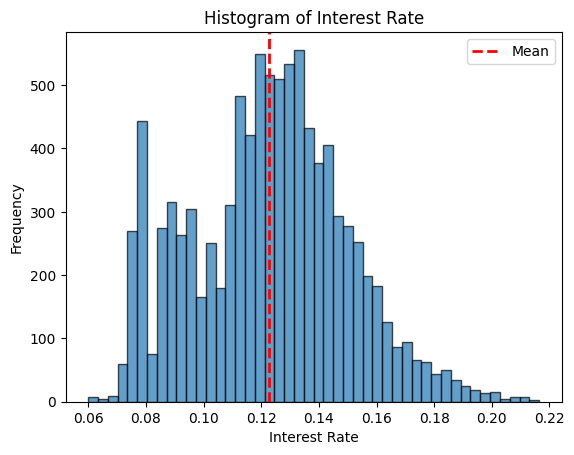

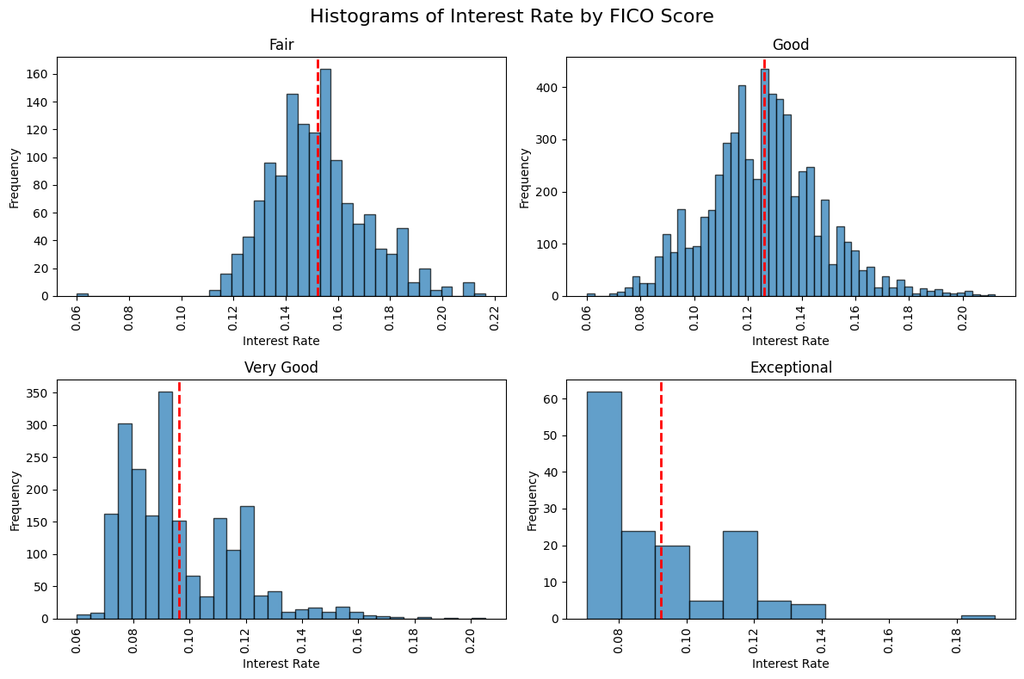

```python
mean = df["int.rate"].mean()
std = df["int.rate"].std()

# Histogram of int.rate
plt.hist(df["int.rate"], bins="auto", alpha=0.7, edgecolor="black")
plt.title("Histogram of Interest Rate")
plt.xlabel("Interest Rate")
plt.ylabel("Frequency")
plt.axvline(mean, linestyle='--', color="red", linewidth=2, label='Mean')

plt.legend()
plt.savefig(fig_dir / f"hist_int.rate.png", dpi=300)
plt.show()

means = df.groupby('fico.score.labels')['int.rate'].mean()
# Interest Rate by FICO scores: Higher scores pay less interest rates as expected
axes = df.hist(column='int.rate', by='fico.score.labels', bins='auto', layout=(2,2), figsize=(12,8), sharex=False,
               grid=False, alpha=0.7, edgecolor='black').flatten()
# Tidy up labels
for ax, m in zip(axes, means):
    ax.set_xlabel("Interest Rate")
    ax.set_ylabel("Frequency")
    ax.axvline(m, color='red', linestyle='--', linewidth=2)

fig = plt.gcf()  # get the current Figure
fig.suptitle("Histograms of Interest Rate by FICO Score", fontsize=16)
plt.tight_layout()
plt.savefig(fig_dir / f"hist_int.rate_by_fico.png", dpi=300)
plt.show()
```

## Log of annual income (log.annual.inc)

Log of annual income resembles a normal distributions but with slithly fatter tails.

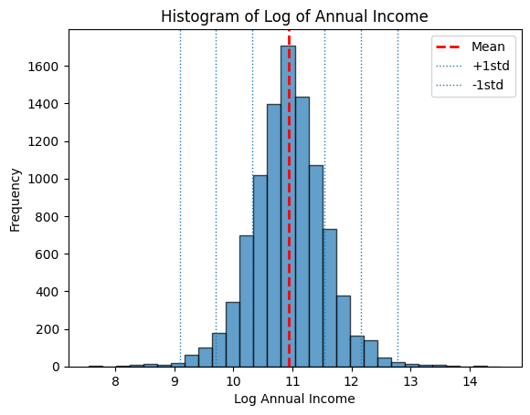

```python
# Central tendency and spread
mean = df["log.annual.inc"].mean()
std = df["log.annual.inc"].std()

# Histogram of annual income
plt.hist(df["log.annual.inc"], bins=30, alpha=0.7, edgecolor="black")
plt.title("Histogram of Log of Annual Income")
plt.xlabel("Log Annual Income")
plt.ylabel("Frequency")
plt.axvline(mean, linestyle='--', linewidth=2, color="red", label='Mean')

for n in [1, 2, 3]:
    plt.axvline(mean + n*std, linestyle=':', linewidth=1, label=f'+{n}std' if n == 1 else "")
    plt.axvline(mean - n*std, linestyle=':', linewidth=1, label=f'-{n}std' if n == 1 else "")

plt.legend()
plt.savefig(fig_dir / f"hist_log.annual.inc.png", dpi=300)
plt.show()
```

## Purpose of the loan (purpose)

We can see bar plot with the most common categories of loan purpose. Debt consolidation seems to be the most common followed all other and credit card, which account for for more than 70% of total. In the second graph with loan purpose grouped by different FICO scores, the main loan purpose differ greatly.

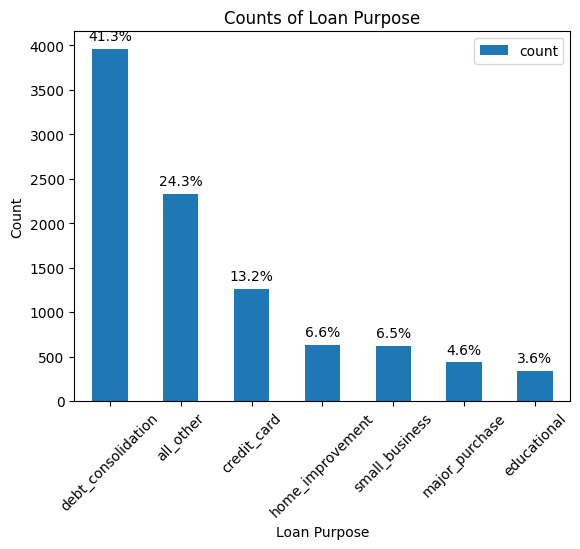

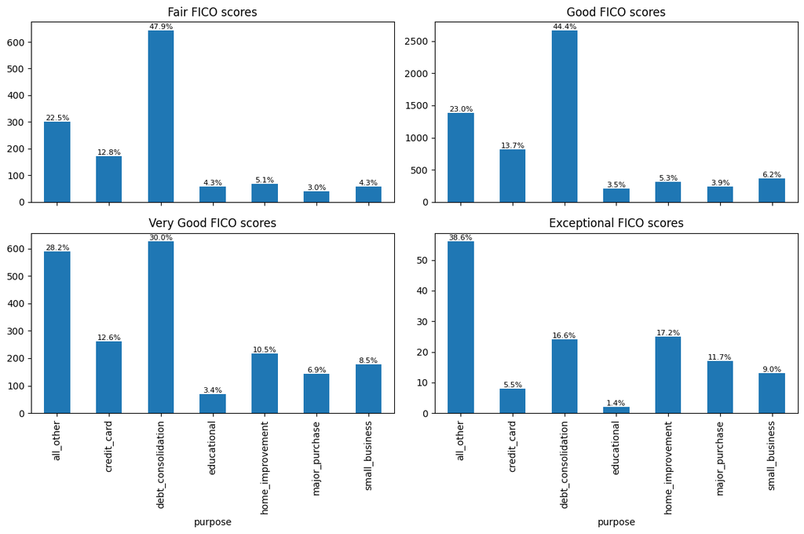

```python
# Purpose of loan
purpose_count = df["purpose"].value_counts(sort=True)
total = purpose_count.sum()

# Bar graph
purpose_count.plot.bar()
plt.title("Counts of Loan Purpose")
plt.xlabel("Loan Purpose")
plt.xticks(rotation=45)
plt.ylabel("Count")
plt.legend().set_visible(False)  # legend not useful here

# Add percentage labels on top of each bar
for i, count in enumerate(purpose_count):
    percent = count / total * 100
    plt.text(i, count + total * 0.01, f"{percent:.1f}%", ha='center')

plt.legend()
plt.savefig(fig_dir / f"bar_purpose.png", dpi=300)
plt.show()

# Pivot to get one column per FICO bucket
purpose_by_fico = (
    df
      .groupby(['purpose','fico.score.labels'])
      .size()
      .unstack(fill_value=0)
)

# Plot every column as its own subplot
axes = purpose_by_fico.plot.bar(subplots=True, layout=(2, 2), figsize=(12, 8), legend=False, rot=90, color="#1f77b4").flatten()

# Annotate percentages on each bar
for ax, label in zip(axes, purpose_by_fico.columns):
    counts = purpose_by_fico[label]
    total = counts.sum()
    for bar in ax.patches:
        height = bar.get_height()
        pct = height / total * 100
        ax.text( bar.get_x() + bar.get_width()/2, height, f"{pct:.1f}%", ha='center', va='bottom', fontsize='8')
    ax.set_title(f"{label} FICO scores")

plt.tight_layout()
plt.savefig(fig_dir / f"bar_purpose_by_fico.png", dpi=300)
plt.show()
```

## Installment (installment)

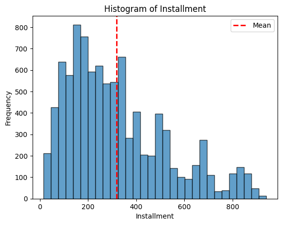

```
fico.score.labels
Fair           271.866861
Good           325.371793
Very Good      328.606710
Exceptional    358.700621
Name: installment, dtype: float64
```

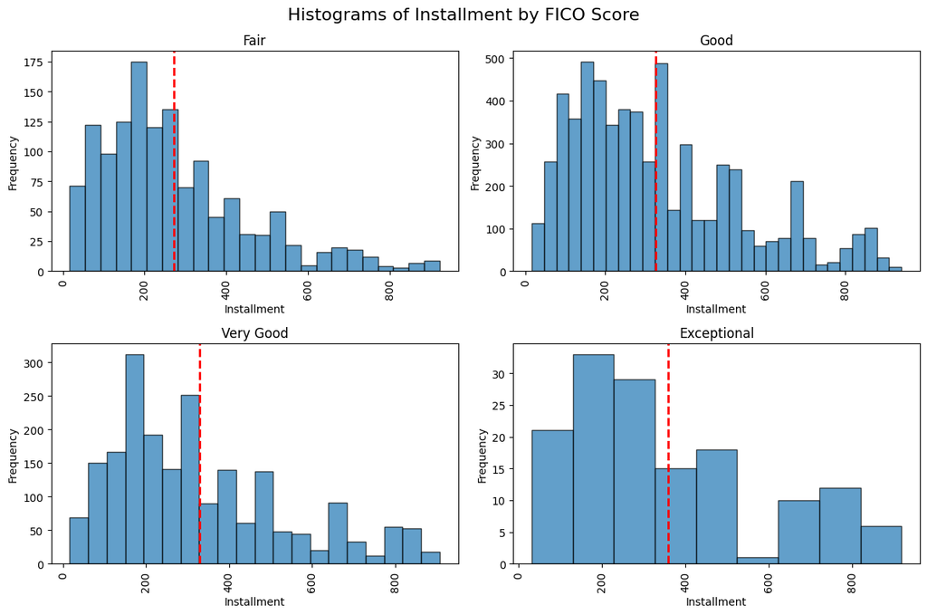

```python
# Central tendency and spread
mean = df["installment"].mean()

# Histogram of annual income
plt.hist(df["installment"], bins=30, alpha=0.7, edgecolor="black")
plt.title("Histogram of Installment")
plt.xlabel("Installment")
plt.ylabel("Frequency")
plt.axvline(mean, linestyle='--', color="red", linewidth=2, label='Mean')

plt.legend()
plt.savefig(fig_dir / f"hist_installment.png", dpi=300)
plt.show()

means = df.groupby('fico.score.labels')['installment'].mean()
print(means)
# Interest Rate by FICO scores: Higher scores pay less interest rates as expected
axes = df.hist(column='installment', by='fico.score.labels', bins='auto', layout=(2,2), figsize=(12, 8), sharex=False,
                grid=False, alpha=0.7, edgecolor='black').flatten()

# Tidy up labels
for ax, m in zip(axes, means):
    ax.set_xlabel("Installment")
    ax.set_ylabel("Frequency")
    ax.axvline(m, color='red', linestyle='--', linewidth=2)

fig = plt.gcf()  # get the current Figure
fig.suptitle("Histograms of Installment by FICO Score", fontsize=16)
plt.tight_layout()
plt.savefig(fig_dir / f"hist_installment_by_fico.png", dpi=300)
plt.show()
```

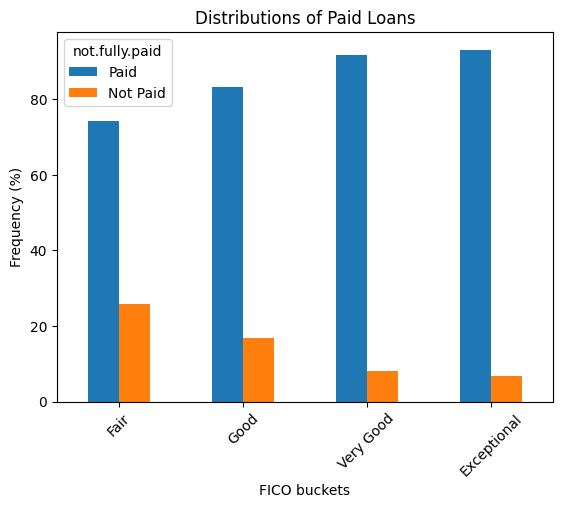

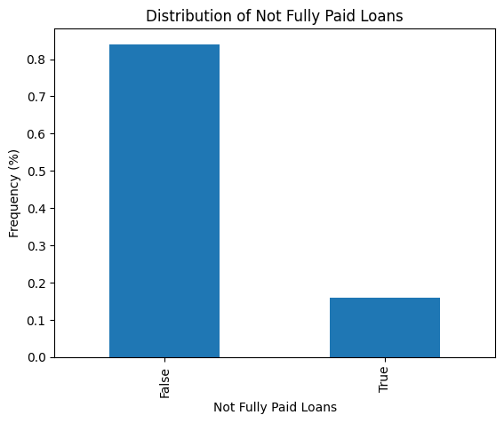

```python
counts = ( df
    .groupby(['fico.score.labels','not.fully.paid'])
    .size()
    .unstack(fill_value=0)
)
counts = counts.rename(columns={0: "Paid", 1: "Not Paid"})

# Add total & convert to percentages
counts["total"]   = counts.sum(axis=1)
counts["Paid"]    = counts["Paid"]     / counts["total"] * 100
counts["Not Paid"] = counts["Not Paid"] / counts["total"] * 100
counts = counts.drop("total", axis=1)

# Bar plot
counts.plot.bar(rot=45)
plt.title("Distributions of Paid Loans")
plt.xlabel("FICO buckets")
plt.ylabel("Frequency (%)")
plt.savefig(fig_dir / f"bar_not.fully.paid_by_fico.png", dpi=300)
plt.show()

counts = df['not.fully.paid'].value_counts(sort=True)
counts['percentages'] = counts / counts.sum()
counts['percentages'].plot.bar()
plt.xlabel("Not Fully Paid Loans")
plt.ylabel("Frequency (%)")
plt.title("Distribution of Not Fully Paid Loans")
plt.savefig(fig_dir / f"bar_not.fully.paid.png", dpi=300)
plt.show()
```

## Feature selection

Columns to maintain for ML models:

- `credit.poicy`: significant difference in distribution for `not.fully.paid` loans. Good binary variable
- `purpose`: significant difference in distribution for `not.fully.paid` loans. Good categorical variable
- `fico`: fico by itself seems to reasonable be a good predictor of default by it's highly correlated with other variables such as `int.rate`. It has a considerable difference in distribution for `no.fully.paid` loans and has a high variance.
- `revol.util`: Has a considerable variance and differs significatly in distibution for `not.fully.paid` loans.
- `inq.last6mths`: Has a considerable difference in the distribution for `not.fully.paid` loans by default status. However it's moderatly correlated with other possible features such as `int.rate` and `fico` and has a low variance.

```python
# Maybe drop: int.rate
selected_cols = ['credit.policy', 'revol.util', 'fico',  'inq.last.6mths', 'purpose']

# Create features and target data sets: drop redundant features
df_selected = df[selected_cols]

# Create features and targer data frames
features = df_selected
target = df["not.fully.paid"]

# Write features and target data sets
features.to_csv("../data/processed/features.csv", index=False)
target.to_csv("../data/processed/target.csv", index=False)
```